# TUGAS MINGGU 3 MPDW

Fajryanti Kusuma Wardani

2023-09-15

```r
#PACKAGES
library(dLagM)
library(dynlm)
library(MLmetrics)
library(lmtest)
library(car)
#IMPOR DATA
#Menggunakan data praktikum minggu kedua
library("rio")
data <- import("https://raw.githubusercontent.com/fajryanti/mpdw-p1/main/PRAKTIKUM%20MINGGU%202/new%20delhi%20air%20quality.csv")
str(data)
```

```
## 'data.frame':    72 obs. of  12 variables:
##  $ V1             : int  0 1 2 3 4 5 6 7 8 9 ...
##  $ AQI            : num  30.2 28.2 26.6 25 26 26 26 24 23 24 ...
##  $ CO             : num  199 198 199 202 205 ...
##  $ datetime       : chr  "2022-10-21:18" "2022-10-21:19" "2022-10-21:20" "2022-10-21:21" ...
##  $ no2            : num  0.0469 0.0465 0.0469 0.0482 0.0489 ...
##  $ o3             : num  55.8 54.9 54.6 55.1 55.8 ...
##  $ pm10           : num  10.5 10.7 11.2 11.1 10.4 ...
##  $ pm25           : num  5.64 4.62 3.52 2.23 1.98 ...
##  $ so2            : num  0.387 0.41 0.402 0.376 0.339 ...
##  $ timestamp_local: POSIXct, format: "2022-10-21 23:00:00" "2022-10-22 00:00:00" ...
##  $ timestamp_utc  : POSIXct, format: "2022-10-21 18:00:00" "2022-10-21 19:00:00" ...
##  $ ts             : int  1666375200 1666378800 1666382400 1666386000 1666389600 1666393200 1666396800 1666400400 1666404000 1666407600 ...
```

```r
#SPLIT DATA
train<-data[1:57,]
test<-data[58:72,]
```

```r
#data time series
train.ts<-ts(train)
test.ts<-ts(test)
data.ts<-ts(data)
```

## Model Koyck

### Pemodelan

```r
#MODEL KOYCK
model.koyck <- koyckDlm(x = train$o3, y = train$AQI)
summary(model.koyck)
```

```
##
## Call:
## "Y ~ (Intercept) + Y.1 + X.t"
##
## Residuals:
##       Min        1Q    Median        3Q       Max
## -1.127670 -0.301407  0.001002  0.262601  1.103471
##
## Coefficients:
##             Estimate Std. Error t value Pr(>|t|)
## (Intercept)  0.54798    0.92878   0.590    0.558
## Y.1          0.41955    0.08223   5.102 4.63e-06 ***
## X.t          0.25830    0.04107   6.289 6.25e-08 ***
## ---
## Signif. codes:  0 '***' 0.001 '**' 0.01 '*' 0.05 '.' 0.1 ' ' 1
##
## Residual standard error: 0.5053 on 53 degrees of freedom
## Multiple R-Squared: 0.9463,  Adjusted R-squared: 0.9443
## Wald test: 423.7 on 2 and 53 DF,  p-value: < 2.2e-16
##
## Diagnostic tests:
## NULL
##
##                             alpha      beta       phi
## Geometric coefficients:  0.944071 0.2582957 0.4195528
```

```r
AIC(model.koyck)
```

```
## [1] 87.39413
```

```r
BIC(model.koyck)
```

```
## [1] 95.49554
```

Dari hasil tersebut, didapat bahwa peubah $x_t$ dan $y_{t-1}$ memiliki nilai $P-Value<0.05$. Hal ini menunjukkan bahwa peubah $x_t$ dan $y_{t-1}$ berpengaruh signifikan terhadap $y$. Adapun model keseluruhannya adalah sebagai berikut

$$\hat{Y_t}=0.54798+0.25830X_t+0.41955Y_{t-1}$$

### Peramalan dan Akurasi

Berikut adalah hasil peramalan y untuk 15 periode kedepan menggunakan model koyck

```r
fore.koyck <- forecast(model = model.koyck, x=test$o3, h=15)
fore.koyck
```

```
## $forecasts
##  [1] 24.15387 23.05989 21.95429 21.12094 20.21706 19.74546 20.00947 20.67448
##  [9] 20.95348 21.07054 21.58152 23.08914 24.83015 26.29958 27.28558
##
## $call
## forecast.koyckDlm(model = model.koyck, x = test$o3, h = 15)
##
## attr(,"class")
## [1] "forecast.koyckDlm" "dLagM"
```

```r
mape.koyck <- MAPE(fore.koyck$forecasts, test$AQI)
mape.koyck
```

```
## [1] 0.03187326
```

```r
#akurasi data training
GoF(model.koyck)
```

```
##              n       MAE         MPE       MAPE      sMAPE      MASE       MSE
## model.koyck 56 0.3849916 -0.00049635 0.01435646 0.01433475 0.6015494 0.2416839
##                  MRAE    GMRAE
## model.koyck 589435374 7663.933
```

## Regression with Distributed Lag

### Pemodelan (Lag=2)

```r
model.dlm <- dlm(x = train$o3,y = train$AQI , q = 2)
summary(model.dlm)
```

```
##
## Call:
## lm(formula = model.formula, data = design)
##
## Residuals:
##      Min       1Q   Median       3Q      Max
## -0.45678 -0.35809 -0.02571  0.25176  1.40513
##
## Coefficients:
##              Estimate Std. Error t value Pr(>|t|)
## (Intercept) -0.052782   0.689979  -0.076    0.939
## x.t          0.476379   0.053816   8.852 6.95e-12 ***
## x.1         -0.005756   0.099095  -0.058    0.954
## x.2         -0.008392   0.055411  -0.151    0.880
## ---
## Signif. codes:  0 '***' 0.001 '**' 0.01 '*' 0.05 '.' 0.1 ' ' 1
##
## Residual standard error: 0.3501 on 51 degrees of freedom
## Multiple R-squared:  0.9751, Adjusted R-squared:  0.9736
## F-statistic:   666 on 3 and 51 DF,  p-value: < 2.2e-16
##
## AIC and BIC values for the model:
##       AIC      BIC
## 1 46.4728 56.50947
```

```r
AIC(model.dlm)
```

```
## [1] 46.4728
```

```r
BIC(model.dlm)
```

```
## [1] 56.50947
```

$$\hat{Y_t}=-0.052782+0.476379X_t-0.005756X_{t-1}-0.008392X_{t-2}$$
### Peramalan dan Akurasi

Berikut merupakan hasil peramalan $y$ untuk 15 periode kedepan

```r
fore.dlm <- forecast(model = model.dlm, x=test$o3, h=15)
fore.dlm
```

```
## $forecasts
##  [1] 23.34620 22.02786 20.88178 20.23873 19.24577 19.09976 19.97166 20.98657
##  [9] 20.95921 20.94120 21.79304 24.16788 26.16845 27.46467 28.09365
##
## $call
## forecast.dlm(model = model.dlm, x = test$o3, h = 15)
##
## attr(,"class")
## [1] "forecast.dlm" "dLagM"
```

```r
mape.dlm <- MAPE(fore.dlm$forecasts, test$AQI)
#akurasi data training
GoF(model.dlm)
```

```
##            n       MAE           MPE       MAPE       sMAPE      MASE       MSE
## model.dlm 55 0.2667435 -0.0001491955 0.00988322 0.009894614 0.4286949 0.1136382
##                 MRAE    GMRAE
## model.dlm 1030460869 6714.446
```

### *Lag* Optimum

```r
#penentuan lag optimum
finiteDLMauto(formula = AQI ~ o3,
              data = data.frame(train), q.min = 1, q.max = 6,
              model.type = "dlm", error.type = "AIC", trace = FALSE)
```

```
##   q - k    MASE      AIC      BIC    GMRAE  MBRAE R.Adj.Sq Ljung-Box
## 3     3 0.39875 27.06744 39.00134 6447.089 0.4948  0.98198 0.1072897
```

Berdasarkan output tersebut, lag optimum didapatkan ketika lag=3. Selanjutnya dilakukan pemodelan untuk lag=3

```r
#model dlm dengan lag optimum
model.dlm2 <- dlm(x = train$o3,y = train$AQI , q = 3)
summary(model.dlm2)
```

```
##
## Call:
## lm(formula = model.formula, data = design)
##
## Residuals:
##      Min       1Q   Median       3Q      Max
## -0.45089 -0.32040 -0.00092  0.28547  0.36946
##
## Coefficients:
##             Estimate Std. Error t value Pr(>|t|)
## (Intercept) -0.44192    0.61566  -0.718    0.476
## x.t          0.46804    0.04603  10.169 1.15e-13 ***
## x.1          0.04216    0.10023   0.421    0.676
## x.2         -0.06664    0.10191  -0.654    0.516
## x.3          0.02484    0.04797   0.518    0.607
## ---
## Signif. codes:  0 '***' 0.001 '**' 0.01 '*' 0.05 '.' 0.1 ' ' 1
##
## Residual standard error: 0.292 on 49 degrees of freedom
## Multiple R-squared:  0.9833, Adjusted R-squared:  0.982
## F-statistic: 722.9 on 4 and 49 DF,  p-value: < 2.2e-16
##
## AIC and BIC values for the model:
##        AIC      BIC
## 1 27.06744 39.00134
```

```r
AIC(model.dlm2)
```

```
## [1] 27.06744
```

```r
BIC(model.dlm2)
```

```
## [1] 39.00134
```

$$\hat{Y_t}=-0.44192+0.46804X_t+0.04216X_1-0.06664X_{t-2}+0.02484X_{t-3}$$

Adapun hasil peramalan 15 periode kedepan menggunakan model tersebut adalah sebagai berikut

```r
#peramalan dan akurasi
fore.dlm2 <- forecast(model = model.dlm2, x=test$o3, h=15)
mape.dlm2<- MAPE(fore.dlm2$forecasts, test$AQI)
#akurasi data training
GoF(model.dlm2)
```

```
##             n       MAE           MPE        MAPE       sMAPE      MASE
## model.dlm2 54 0.2407575 -9.475428e-05 0.008900141 0.008894196 0.3987545
##                   MSE      MRAE    GMRAE
## model.dlm2 0.07739366 992810458 6447.089
```

Model tersebut merupakan model yang sangat baik dengan nilai MAPE yang kurang dari 10%.

## Model Autoregressive

### Pemodelan

```r
model.ardl <- ardlDlm(x = train$o3, y = train$AQI, p = 1 , q = 1)
summary(model.ardl)
```

```
##
## Time series regression with "ts" data:
## Start = 2, End = 57
##
## Call:
## dynlm(formula = as.formula(model.text), data = data, start = 1)
##
## Residuals:
##     Min      1Q  Median      3Q     Max
## -1.0261 -0.2582  0.1254  0.2988  0.8683
##
## Coefficients:
##             Estimate Std. Error t value Pr(>|t|)
## (Intercept) -0.14906    0.67926  -0.219    0.827
## X.t          0.47821    0.03429  13.946  < 2e-16 ***
## X.1         -0.22331    0.04692  -4.759 1.59e-05 ***
## Y.1          0.45264    0.06656   6.801 1.03e-08 ***
## ---
## Signif. codes:  0 '***' 0.001 '**' 0.01 '*' 0.05 '.' 0.1 ' ' 1
##
## Residual standard error: 0.3812 on 52 degrees of freedom
## Multiple R-squared:   0.97,  Adjusted R-squared:  0.9683
## F-statistic: 561.2 on 3 and 52 DF,  p-value: < 2.2e-16
```

```r
AIC(model.ardl)
```

```
## [1] 56.75817
```

```r
BIC(model.ardl)
```

```
## [1] 66.88493
```

$$\hat{Y}=-0,14906+0,47821X_t-0,22331X_{t-1}+0,45264Y_{t-1}$$

### *Lag* Optimum

```r
#penentuan lag optimum
model.ardl.opt <- ardlBoundOrders(data = data.frame(data), ic = "AIC",
                                  formula = AQI ~ o3 )
min_p=c()
for(i in 1:6){
  min_p[i]=min(model.ardl.opt$Stat.table[[i]])
}
q_opt=which(min_p==min(min_p, na.rm = TRUE))
p_opt=which(model.ardl.opt$Stat.table[[q_opt]] ==
              min(model.ardl.opt$Stat.table[[q_opt]], na.rm = TRUE))
data.frame("q_optimum" = q_opt, "p_optimum" = p_opt,
           "AIC"=model.ardl.opt$min.Stat)
```

```
##   q_optimum p_optimum      AIC
## 1         2        13 16.55044
```

Dari tabel di atas, dapat terlihat bahwa nilai AIC terendah didapat ketika $p=13$ dan $q=2$, yaitu sebesar `16.55044`. Artinya, model autoregressive optimum didapat ketika $p=13$ dan $q=2$.

## Pemodelan DLM & ARDL dengan Library `dynlm`

```r
#sama dengan model dlm q=1
cons_lm1 <- dynlm(AQI ~ o3+L(o3),data = train.ts)
cons_lm1
```

```
##
## Time series regression with "ts" data:
## Start = 2, End = 57
##
## Call:
## dynlm(formula = AQI ~ o3 + L(o3), data = train.ts)
##
## Coefficients:
## (Intercept)           o3        L(o3)
##     0.46584      0.46014     -0.00586
```

```r
#sama dengan model ardl p=1 q=0
cons_lm2 <- dynlm(AQI ~ o3+L(AQI),data = train.ts)
cons_lm2
```

```
##
## Time series regression with "ts" data:
## Start = 2, End = 57
##
## Call:
## dynlm(formula = AQI ~ o3 + L(AQI), data = train.ts)
##
## Coefficients:
## (Intercept)           o3       L(AQI)
##     -0.2799       0.3571       0.2368
```

```r
#sama dengan ardl p=1 q=1
cons_lm3 <- dynlm(AQI ~ o3+L(o3)+L(AQI),data = train.ts)
cons_lm3
```

```
##
## Time series regression with "ts" data:
## Start = 2, End = 57
##
## Call:
## dynlm(formula = AQI ~ o3 + L(o3) + L(AQI), data = train.ts)
##
## Coefficients:
## (Intercept)           o3        L(o3)       L(AQI)
##     -0.1491       0.4782      -0.2233       0.4526
```

```r
#sama dengan dlm p=2
cons_lm4 <- dynlm(AQI ~ o3+L(o3)+L(o3,2),data = train.ts)
cons_lm4
```

```
##
## Time series regression with "ts" data:
## Start = 3, End = 57
##
## Call:
## dynlm(formula = AQI ~ o3 + L(o3) + L(o3, 2), data = train.ts)
##
## Coefficients:
## (Intercept)           o3        L(o3)     L(o3, 2)
##   -0.052782     0.476379    -0.005756    -0.008392
```

### Ringkasan Model

```r
summary(cons_lm1)
```

```
##
## Time series regression with "ts" data:
## Start = 2, End = 57
##
## Call:
## dynlm(formula = AQI ~ o3 + L(o3), data = train.ts)
##
## Residuals:
##      Min       1Q   Median       3Q      Max
## -0.51031 -0.40204 -0.09081  0.21207  2.78493
##
## Coefficients:
##             Estimate Std. Error t value Pr(>|t|)
## (Intercept)  0.46584    0.91660   0.508    0.613
## o3           0.46014    0.04655   9.886 1.26e-13 ***
## L(o3)       -0.00586    0.04676  -0.125    0.901
## ---
## Signif. codes:  0 '***' 0.001 '**' 0.01 '*' 0.05 '.' 0.1 ' ' 1
##
## Residual standard error: 0.519 on 53 degrees of freedom
## Multiple R-squared:  0.9434, Adjusted R-squared:  0.9413
## F-statistic: 441.6 on 2 and 53 DF,  p-value: < 2.2e-16
```

```r
summary(cons_lm2)
```

```
##
## Time series regression with "ts" data:
## Start = 2, End = 57
##
## Call:
## dynlm(formula = AQI ~ o3 + L(AQI), data = train.ts)
##
## Residuals:
##      Min       1Q   Median       3Q      Max
## -0.78961 -0.30739 -0.06053  0.20120  1.70996
##
## Coefficients:
##             Estimate Std. Error t value Pr(>|t|)
## (Intercept) -0.27989    0.80546  -0.347 0.729596
## o3           0.35714    0.02728  13.091  < 2e-16 ***
## L(AQI)       0.23682    0.05781   4.096 0.000144 ***
## ---
## Signif. codes:  0 '***' 0.001 '**' 0.01 '*' 0.05 '.' 0.1 ' ' 1
##
## Residual standard error: 0.4524 on 53 degrees of freedom
## Multiple R-squared:  0.957,  Adjusted R-squared:  0.9554
## F-statistic: 589.6 on 2 and 53 DF,  p-value: < 2.2e-16
```

```r
summary(cons_lm3)
```

```
##
## Time series regression with "ts" data:
## Start = 2, End = 57
##
## Call:
## dynlm(formula = AQI ~ o3 + L(o3) + L(AQI), data = train.ts)
##
## Residuals:
##     Min      1Q  Median      3Q     Max
## -1.0261 -0.2582  0.1254  0.2988  0.8683
##
## Coefficients:
##             Estimate Std. Error t value Pr(>|t|)
## (Intercept) -0.14906    0.67926  -0.219    0.827
## o3           0.47821    0.03429  13.946  < 2e-16 ***
## L(o3)       -0.22331    0.04692  -4.759 1.59e-05 ***
## L(AQI)       0.45264    0.06656   6.801 1.03e-08 ***
## ---
## Signif. codes:  0 '***' 0.001 '**' 0.01 '*' 0.05 '.' 0.1 ' ' 1
##
## Residual standard error: 0.3812 on 52 degrees of freedom
## Multiple R-squared:   0.97,  Adjusted R-squared:  0.9683
## F-statistic: 561.2 on 3 and 52 DF,  p-value: < 2.2e-16
```

```r
summary(cons_lm4)
```

```
##
## Time series regression with "ts" data:
## Start = 3, End = 57
##
## Call:
## dynlm(formula = AQI ~ o3 + L(o3) + L(o3, 2), data = train.ts)
##
## Residuals:
##      Min       1Q   Median       3Q      Max
## -0.45678 -0.35809 -0.02571  0.25176  1.40513
##
## Coefficients:
##              Estimate Std. Error t value Pr(>|t|)
## (Intercept) -0.052782   0.689979  -0.076    0.939
## o3           0.476379   0.053816   8.852 6.95e-12 ***
## L(o3)       -0.005756   0.099095  -0.058    0.954
## L(o3, 2)    -0.008392   0.055411  -0.151    0.880
## ---
## Signif. codes:  0 '***' 0.001 '**' 0.01 '*' 0.05 '.' 0.1 ' ' 1
##
## Residual standard error: 0.3501 on 51 degrees of freedom
## Multiple R-squared:  0.9751, Adjusted R-squared:  0.9736
## F-statistic:   666 on 3 and 51 DF,  p-value: < 2.2e-16
```

### SSE

```r
deviance(cons_lm1)
```

```
## [1] 14.27771
```

```r
deviance(cons_lm2)
```

```
## [1] 10.84775
```

```r
deviance(cons_lm3)
```

```
## [1] 7.556756
```

```r
deviance(cons_lm4)
```

```
## [1] 6.250103
```

### Uji Diagnostik

```r
#uji model
if(require("lmtest")) encomptest(cons_lm1, cons_lm2)
```

```
## Encompassing test
##
## Model 1: AQI ~ o3 + L(o3)
## Model 2: AQI ~ o3 + L(AQI)
## Model E: AQI ~ o3 + L(o3) + L(AQI)
##           Res.Df Df      F    Pr(>F)
## M1 vs. ME     52 -1 46.249 1.029e-08 ***
## M2 vs. ME     52 -1 22.646 1.592e-05 ***
## ---
## Signif. codes:  0 '***' 0.001 '**' 0.01 '*' 0.05 '.' 0.1 ' ' 1
```

#### Autokorelasi

```r
#durbin watson
dwtest(cons_lm1)
```

```
##
##  Durbin-Watson test
##
## data:  cons_lm1
## DW = 1.0904, p-value = 5.766e-05
## alternative hypothesis: true autocorrelation is greater than 0
```

```r
dwtest(cons_lm2)
```

```
##
##  Durbin-Watson test
##
## data:  cons_lm2
## DW = 1.687, p-value = 0.07733
## alternative hypothesis: true autocorrelation is greater than 0
```

```r
dwtest(cons_lm3)
```

```
##
##  Durbin-Watson test
##
## data:  cons_lm3
## DW = 2.7592, p-value = 0.9954
## alternative hypothesis: true autocorrelation is greater than 0
```

```r
dwtest(cons_lm4)
```

```
##
##  Durbin-Watson test
##
## data:  cons_lm4
## DW = 2.1325, p-value = 0.5819
## alternative hypothesis: true autocorrelation is greater than 0
```

#### Heterogenitas

```r
bptest(cons_lm1)
```

```
##
##  studentized Breusch-Pagan test
##
## data:  cons_lm1
## BP = 1.2214, df = 2, p-value = 0.543
```

```r
bptest(cons_lm2)
```

```
##
##  studentized Breusch-Pagan test
##
## data:  cons_lm2
## BP = 22.69, df = 2, p-value = 1.183e-05
```

```r
bptest(cons_lm3)
```

```
##
##  studentized Breusch-Pagan test
##
## data:  cons_lm3
## BP = 13.511, df = 3, p-value = 0.003653
```

```r
bptest(cons_lm4)
```

```
##
##  studentized Breusch-Pagan test
##
## data:  cons_lm4
## BP = 0.93628, df = 3, p-value = 0.8167
```

#### Kenormalan

```r
shapiro.test(residuals(cons_lm1))
```

```
##
##  Shapiro-Wilk normality test
##
## data:  residuals(cons_lm1)
## W = 0.69289, p-value = 1.56e-09
```

```r
shapiro.test(residuals(cons_lm2))
```

```
##
##  Shapiro-Wilk normality test
##
## data:  residuals(cons_lm2)
## W = 0.93188, p-value = 0.003549
```

```r
shapiro.test(residuals(cons_lm3))
```

```
##
##  Shapiro-Wilk normality test
##
## data:  residuals(cons_lm3)
## W = 0.96195, p-value = 0.07469
```

```r
shapiro.test(residuals(cons_lm4))
```

```
##
##  Shapiro-Wilk normality test
##
## data:  residuals(cons_lm4)
## W = 0.84042, p-value = 3.659e-06
```

## Perbandingan Model

```r
akurasi <- matrix(c(mape.koyck, mape.dlm, mape.dlm2))
row.names(akurasi)<- c("Koyck","DLM 1","DLM 2")
colnames(akurasi) <- c("MAPE")
akurasi
```

```
##              MAPE
## Koyck 0.031873255
## DLM 1 0.006820359
## DLM 2 0.007516799
```

Berdasarkan nilai MAPE, model paling optimum didapat pada DLM 1 karena memiliki nilai MAPE yang terkecil.

### Plot

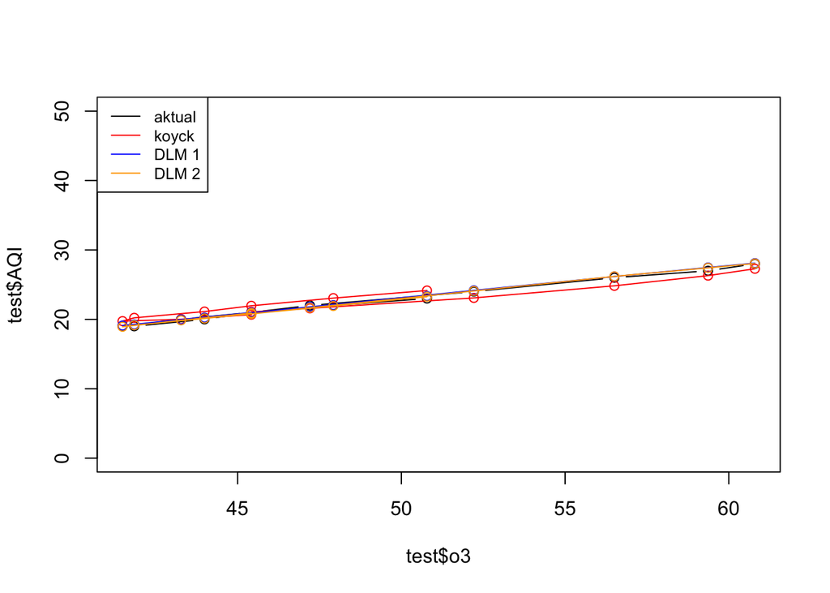

```r
par(mfrow=c(1,1))
plot(test$o3, test$AQI, type="b", col="black", ylim=c(0,50))
points(test$o3, fore.koyck$forecasts,col="red")
lines(test$o3, fore.koyck$forecasts,col="red")
points(test$o3, fore.dlm$forecasts,col="blue")
lines(test$o3, fore.dlm$forecasts,col="blue")
points(test$o3, fore.dlm2$forecasts,col="orange")
lines(test$o3, fore.dlm2$forecasts,col="orange")
legend("topleft",c("aktual", "koyck","DLM 1","DLM 2"), lty=1, col=c("black","red","blue","orange"), cex=0.8)
```

Berdasarkan plot tersebut, terlihat bahwa plot yang paling mendekati data aktualnya adalah DLM 1, sehingga dapat disimpulkan model terbaik dalam hal ini adalah DLM 1